# R Essentials

### Scatterplots

Scatterplots are great for showing bivariate relationships between continuous variables. (If one of your variables is a factor, then use a boxplot.) We might expect to find that abalone length and weight are correlated. Here is a scatterplot of length against weight with an ordinary least squares (OLS) line added to summarize the linear relationship:

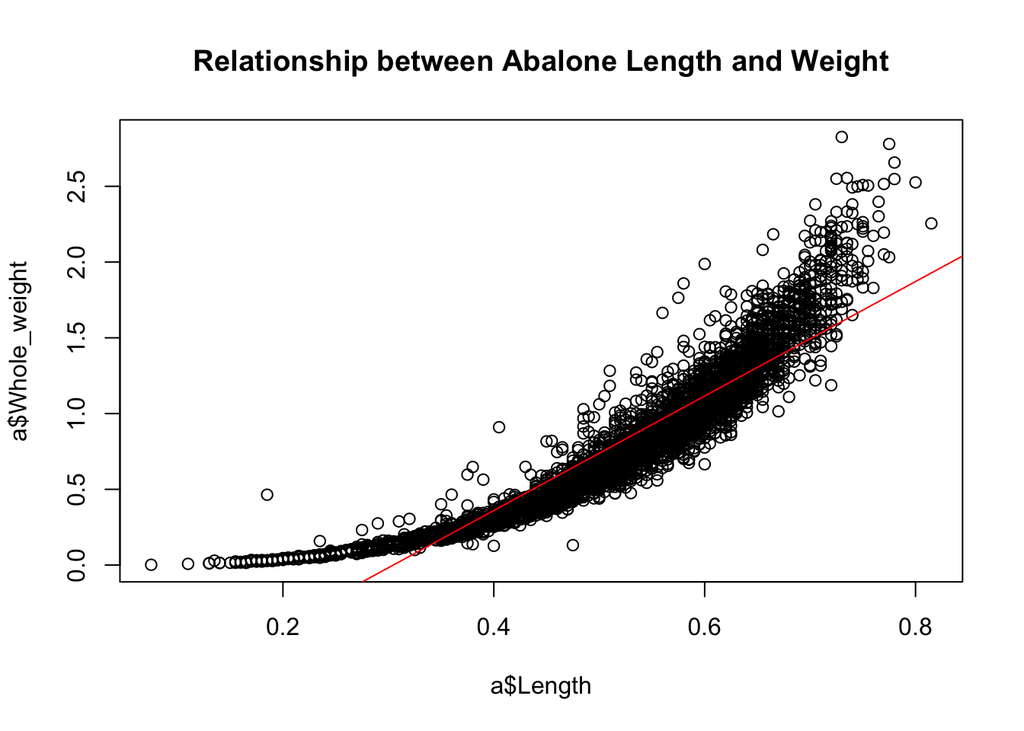

```r
plot(a$Whole_weight~a$Length,
     main="Relationship between Abalone Length and Weight")
abline(lm(a$Whole_weight~a$Length), col="red")
```

Notice that we have used the `lm()` function—the main R function for fitting linear models—to add the OLS line. R knows how to extract the intercept and slope from the model object created by `lm()`. Clearly, however, this is a lousy linear model; the data displays an upward curve that might be better captured with a quadratic term in the model.

A plot showing a nonlinear fit can certainly be produced in base R graphics but is not entirely straightforward: this, task, too, we leave for the next chapter with `ggplot2`.  
One thing we can accomplish fairly easily here is to color the points according to sex. Given the sex differences we’ve observed so far, it might well be the case that they explain this nonlinear relationship. It is, at any rate, worth a look. The following plot colors points by sex, which allows us to visualize how a bivariate relationship—the one between length and weight—varies by sex. Later we will describe this variation across levels of a factor as an *interaction*. Here length and sex interact to explain weight.

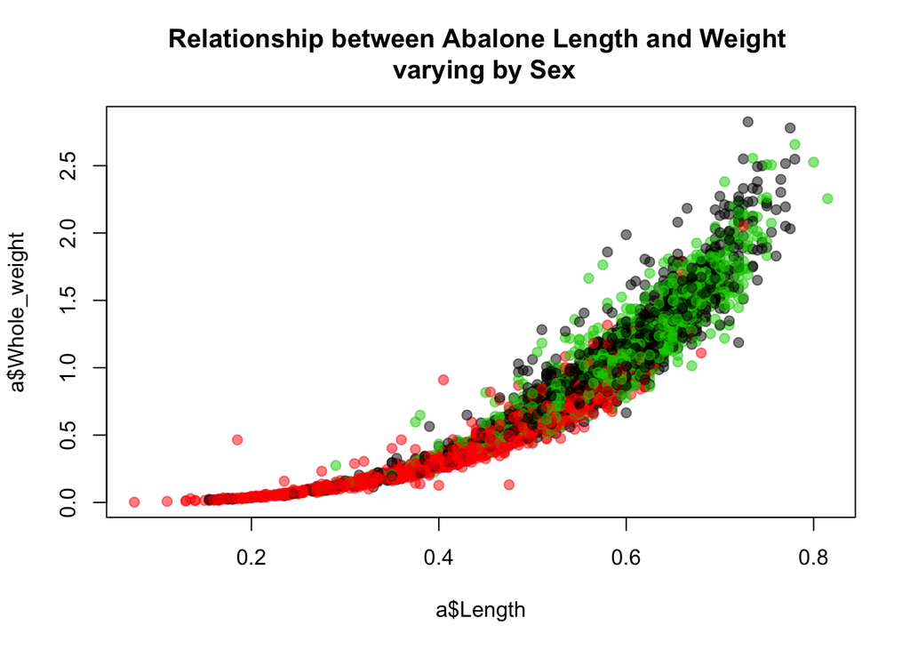

```r
library(scales)
plot(a$Whole_weight~a$Length,
     main="Relationship between Abalone Length and Weight \n varying by Sex",
     col = alpha(as.numeric(a$Sex), 0.5), pch=19)
```

I have added transparency to the points (making the points behind somewhat visible) so we can better see which regions of the distribution are dominated by the different groups.

One possibility for what is going on here—that could be explored further—is that the indeterminate abalone are smaller than males and females, in terms of both length and weight, and that what looks like a nonlinear relationship between length and weight is actually just a linear relationship that varies by group. Plotting these separate fits to investigate this idea is, again, sort of a pain in base R.

We will revisit this topic—displaying linear fits to subsets of the data in the same plot—in the next chapter using `ggplot2`.

### Scatterplot matrix

R has many functions for producing multi-panel plots that display bivariate relationships among all the variables in a data set. Here is one implementation.

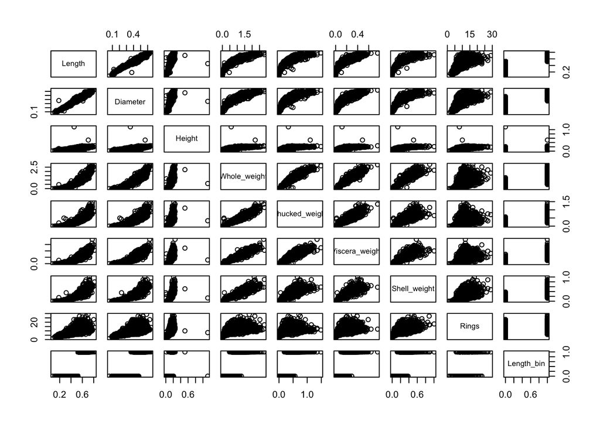

```r
pairs(a[,-1])
```

[^1]: To follow this tutorial, type (or copy and paste) the code examples into your RStudio console and press return. You may, alternatively, open an R script (a .R document) by clicking on the `File` menu option. Select `New File` > `R script`. Type (or copy and paste) the code examples into your practice script, then highlight them and press `control-return` to run them.
[^2]: `mtcars` contains information on the design and performance characteristics of older model cars (1973-4).
[^3]: If you need information about an R function, you may type “?” in the console followed by the function: for example, `?head`. In RStudio this will automatically bring up the documentation for that function under the “Help” tab of the plot pane. The documentation contains comprehensive information about the arguments to the function, details on usage, the values returned, along with examples. In the case of `head()` there are two non-optional arguments: `x` (data) and `n` (size), which has a default value of 6. If an argument has a default setting, and you leave it blank, R will use automatically use that default. R functions recognize arguments either by name or position. Thus, because the `head()` expects first a data argument then a size argument, these two uses of `head()` are identical: `head(mtcars, n = 10)` and `head(mtcars, 10)`.
[^4]: The hinges are actually “versions” of the first and third quartiles. See the documentation for `boxplot.stats()` for details.